# SPEW Output Summary

Synthetic Populations and Ecosystems of the World

[figure not shown]

# ALABAMA

There is/are 2 level(s) of nested ecosystems in Alabama.

There is/are 1176 lowest level subregions.

## Data

The raw counts, microdata, and shapefiles are from the US Census.

## Maps

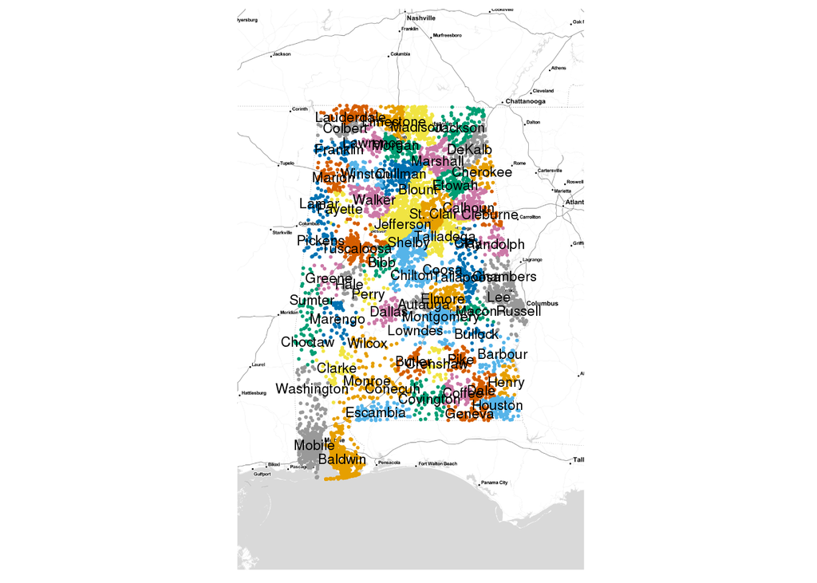

The above map shows a sub-sample of the different sub regions. Each region has a sample of up to 10,000 households.

## Synthetic Households

**Total Synthetic Households:** 2,146,513

### Summaries

Below is a bar chart of the number of households in each region.

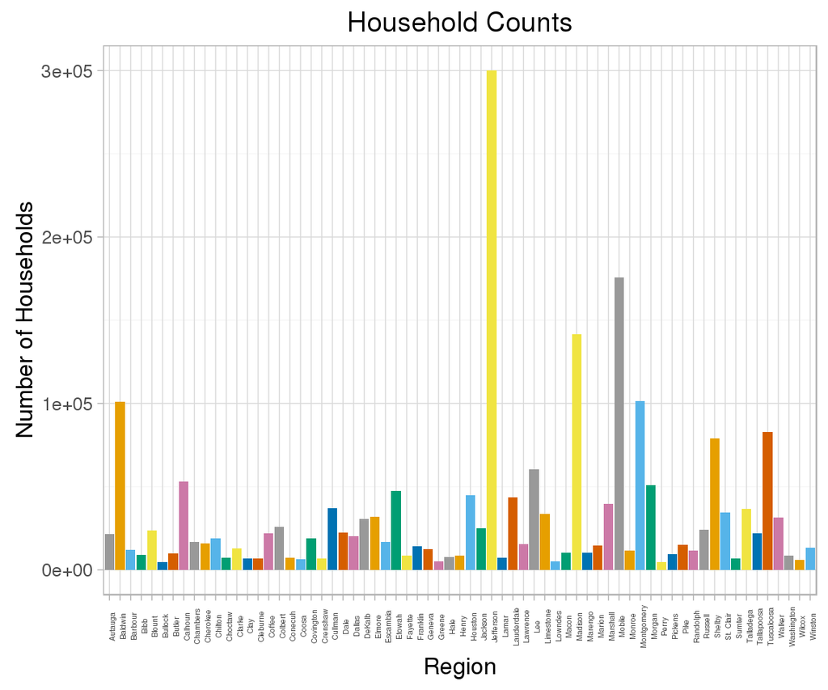

### Column Names

There are 2 columns in the synthetic household ecosystem. They are:

```
## [1] "longitude" "latitude"
```

## Synthetic Persons

**Total Synthetic Persons:** 4,456,027

### Summaries

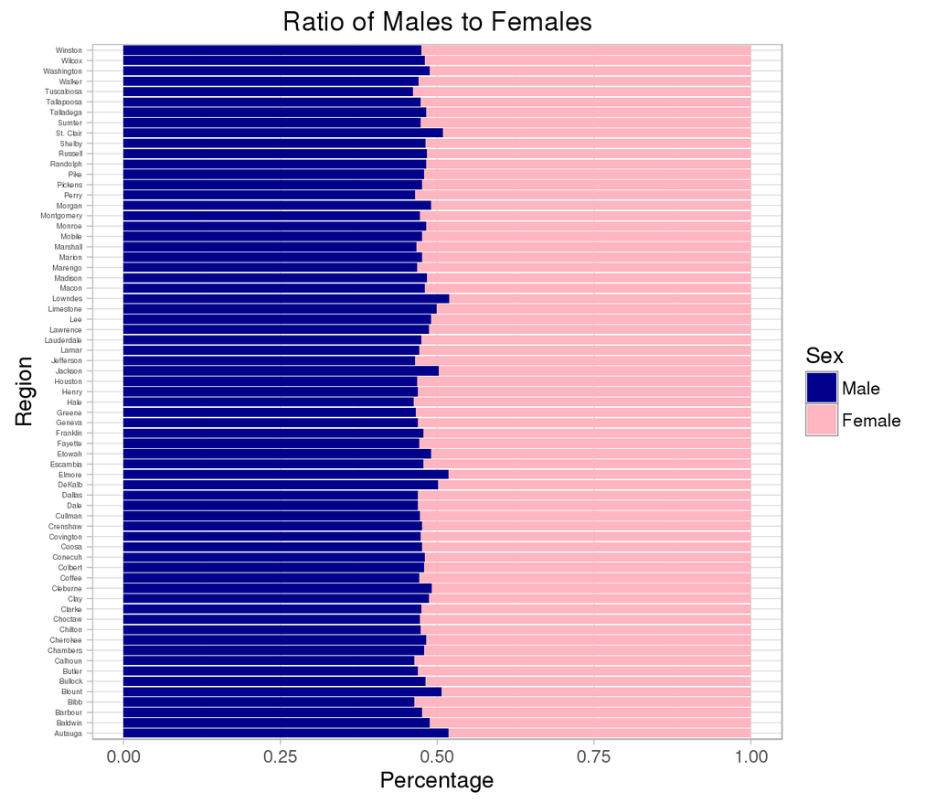

### Column Names

```
## [1] "SEX"      "puma_id"  "place_id"
```

## Generation Information

This report was generated on 2016-09-28 16:35:28 by `spew`, an `R` package used to generate populations throughout the world. Please see our [spew Github repo](https://github.com/leerichardson/spew) and our previously generated regions at [epimodels.org](http://www.epimodels.org/drupal/?q=node/32). We are a part of the Infomatics Services Group MIDAS branch at Carnegie Mellon University and University of Pittsburgh and are supported by 1 U24 GM110707-01 NIH/NIGMS grant. Please send your comments and suggestions to bill@cmu.edu.